# Phụ lục 3: Thực nghiệm trên bộ dữ liệu thiếu

Kết quả của thực nghiệm DML thực hiện trên cả 2 bài toán trên có sự nhất quán so với kết quả nghiên cứu của Card và Thornton. Tuy nhiên, bộ dữ liệu đã được thu thập có sự kiểm soát (control) do đó có thể sử dụng Hồi quy tuyến tính để ước lượng ảnh hưởng nhân quả. Chẳng hạn, trong nghiên cứu của David Card, dữ liệu được thu thập bởi NLSYM - là một phần của chương trình National Longitudinal Surveys (NLS) được thực hiện bởi Cục Thống kê Lao động Hoa Kỳ (Bureau of Labor Statistics - BLS). Do đó bộ dữ liệu có sự kiểm soát cao, dẫn đến các kết quả ước lượng có thể thực hiện bằng *2SLS*.

Trên thực tế, với đa phần dữ liệu thường không được thu thập với phương pháp tốt, hoặc khi dữ liệu được thu thập là dữ liệu quan sát - dữ liệu được thu thập từ các đối tượng trong môi trường tự nhiên của họ mà không có sự can thiệp hay kiểm soát từ nhà nghiên cứu - việc đưa ra ước lượng ảnh hưởng nhân quả sẽ bị thiên lệch. DML có thể xử lý thiên lệch và đưa ra ước lượng tốt hơn hồi quy tuyến tính.

Để có thể mô tả sự ít thiên lệch khi áp dụng DML hơn so với hồi quy tuyến tính, Khóa luận thực hiện giả định loại bỏ các bản ghi trong bộ dữ liệu với mục đích tạo ra thiên lệch, qua đó thực hiện lại hồi quy tuyến tính và DML để đưa ra so sánh về hệ số nhân quả thu được với hệ số nhân quả được ước lượng khi dữ liệu đầy đủ.

Chúng ta sẽ xét lại bài toán Ảnh hưởng của Học vấn đến Thu nhập của David Card và đưa ra phương pháp loại bỏ dữ liệu.

```python
import numpy as np
import pandas as pd
import doubleml as dml
from sklearn.ensemble import RandomForestClassifier, RandomForestRegressor
import matplotlib.pyplot as plt
from causaldata import close_college
import seaborn as sns
from statsmodels.sandbox.regression.gmm import IV2SLS
import matplotlib.ticker as mticker
import statsmodels.api as sm
```

Để mô tả rõ hơn quá trình loại bỏ bản ghi ảnh hưởng đến kết quả ước lượng, các ngưỡng được giảm từ 1 xuống lần lượt từ 0.9, 0.8,... cho đến 0.5.

Việc lựa chọn biến **educ** và biến **nearc4** làm ngưỡng là bởi vì bằng cách loại bỏ dữ liệu trong đó giá trị **educ** cao nhưng **nearc4** bằng 0, chúng ta sẽ tạo ra thiên lệch. Những cá nhân có trình độ học vấn cao nhưng không ở gần trường đại học có thể có động thái tiền lương khác so với những người khác, ảnh hưởng đến ước lượng của mô hình tuyến tính. Cụ thể, những người có trình độ học vấn cao nhưng không ở gần trường đại học có thể có mức lương cao do các kỹ năng hoặc cơ hội khác mà họ đã có được, nhưng không thông qua việc ở gần trường đại học. Khi họ bị loại bỏ, mô hình sẽ không còn phản ánh đúng mối quan hệ giữa học vấn và thu nhập, do đó hệ số của biến **educ** có thể bị thiên lệch.

Việc giảm ngưỡng biến **educ** được thực hiện với mục đích loại bỏ nhiều hơn các bản ghi có **educ** lớn hơn ngưỡng, đồng thời có **nearc4** bằng 0, qua đó làm giảm ảnh hưởng của nearc4 với vai trò là biến công cụ ảnh hưởng đến **educ**, dẫn đến thiên lệch có xu hướng lớn hơn.

```python
df_datas = []

for i in range(6):
    data = close_college.load_pandas().data
    df_data = pd.DataFrame(data)
    df_data = df_data.dropna()
    educ_threshold_high = df_data['educ'].quantile(1-0.1*i)
    df_dropped = df_data[~((df_data['educ'] > educ_threshold_high) & (df_data['nearc4'] == 0))]

    df_datas.append(df_dropped)
```

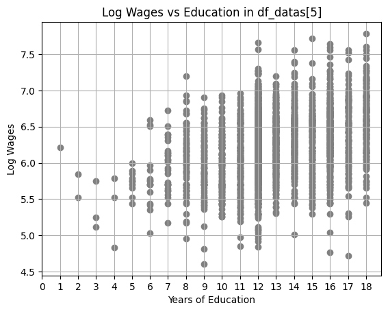

```python
plt.scatter(df_datas[5]['educ'], df_datas[5]['lwage'], color='gray')
plt.title('Log Wages vs Education in df_datas[5]')
plt.xlabel('Years of Education')
plt.ylabel('Log Wages')
plt.xticks(range(0, max(df_datas[5]['educ']) + 1, 1))
plt.grid(True)
plt.show()
```

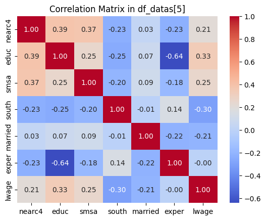

```python
df_data_drop_black = df_datas[5].drop(columns='black')
correlation_matrix = df_data_drop_black.corr()
# Vẽ heatmap của ma trận correlation
sns.heatmap(correlation_matrix, annot=True, cmap='coolwarm', fmt=".2f")
plt.title('Correlation Matrix in df_datas[5]')
plt.show()
```

Kết quả cho thấy không có quá nhiều thay đổi khi xem xét phân bố dữ liệu hay ma trận tương quan.

Chúng ta sẽ thực hiện DML và 2SLS cho từng bộ dữ liệu, sau đó đưa các kết quả vào 1 list tương ứng.

```python
dml_data_bases = []

for i in range(6):
    feature = ['exper', 'married', 'south', 'black', 'smsa']
    instrument_feature = ['nearc4']
    dml_data_base = dml.DoubleMLData(df_datas[i], y_col='lwage', x_cols=feature, d_cols='educ', z_cols=instrument_feature)
    dml_data_bases.append(dml_data_base)
    print(dml_data_bases[i])
```

```
================== DoubleMLData Object ==================

------------------ Data summary      ------------------
Outcome variable: lwage
Treatment variable(s): ['educ']
Covariates: ['exper', 'married', 'south', 'black', 'smsa']
Instrument variable(s): ['nearc4']
No. Observations: 3003

------------------ DataFrame info    ------------------
<class 'pandas.core.frame.DataFrame'>
Index: 3003 entries, 0 to 3009
Columns: 8 entries, nearc4 to lwage
dtypes: float32(1), float64(1), int8(6)
memory usage: 76.2 KB

================== DoubleMLData Object ==================

------------------ Data summary      ------------------
Outcome variable: lwage
Treatment variable(s): ['educ']
Covariates: ['exper', 'married', 'south', 'black', 'smsa']
Instrument variable(s): ['nearc4']
No. Observations: 2962

------------------ DataFrame info    ------------------
<class 'pandas.core.frame.DataFrame'>
Index: 2962 entries, 0 to 3009
Columns: 8 entries, nearc4 to lwage
dtypes: float32(1), float64(1), int8(6)
memory usage: 75.2 KB

================== DoubleMLData Object ==================

------------------ Data summary      ------------------
Outcome variable: lwage
Treatment variable(s): ['educ']
Covariates: ['exper', 'married', 'south', 'black', 'smsa']
Instrument variable(s): ['nearc4']
No. Observations: 2921
```

[output cut: 40 more lines]

```
================== DoubleMLData Object ==================

------------------ Data summary      ------------------
Outcome variable: lwage
Treatment variable(s): ['educ']
Covariates: ['exper', 'married', 'south', 'black', 'smsa']
Instrument variable(s): ['nearc4']
No. Observations: 2688

------------------ DataFrame info    ------------------
<class 'pandas.core.frame.DataFrame'>
Index: 2688 entries, 0 to 3009
Columns: 8 entries, nearc4 to lwage
dtypes: float32(1), float64(1), int8(6)
memory usage: 68.2 KB
```

```python
performance_rf = []
performance_2sls = []
summary_2sls = []
```

```python
ml_l_rf = RandomForestRegressor(n_estimators=100, max_features=20, max_depth=5, min_samples_leaf=2)
ml_m_rf = RandomForestRegressor(n_estimators=100, max_features=20, max_depth=5, min_samples_leaf=2)
ml_r_rf = RandomForestRegressor(n_estimators=100, max_features=20, max_depth=5, min_samples_leaf=2)

for i in range(6):
    np.random.seed(123)
    dml_pliv_obj_rf = dml.DoubleMLPLIV(dml_data_bases[i], ml_l=ml_l_rf, ml_m=ml_m_rf, ml_r=ml_r_rf)
    dml_pliv_obj_rf.fit()
    performance_rf.append(dml_pliv_obj_rf.summary)
    print(performance_rf[i])
```

```
          coef   std err         t     P>|t|     2.5 %    97.5 %
educ  0.123766  0.045021  2.749084  0.005976  0.035527  0.212005
          coef   std err         t     P>|t|     2.5 %    97.5 %
educ  0.119095  0.033162  3.591322  0.000329  0.054099  0.184092
          coef   std err         t     P>|t|     2.5 %    97.5 %
educ  0.100359  0.025339  3.960625  0.000075  0.050695  0.150022
          coef   std err         t         P>|t|     2.5 %    97.5 %
educ  0.105126  0.017765  5.917727  3.264216e-09  0.070308  0.139944
          coef   std err         t         P>|t|     2.5 %    97.5 %
educ  0.090197  0.016451  5.482722  4.188301e-08  0.057953  0.122441
          coef   std err         t         P>|t|     2.5 %    97.5 %
educ  0.076757  0.015223  5.042306  4.599554e-07  0.046921  0.106592
```

```python
for df_data in df_datas:
    Z = df_data[['nearc4']]
    D = df_data[['educ']]
    X = df_data[['exper', 'black', 'south', 'married', 'smsa']]
    y = df_data['lwage']
    X = sm.add_constant(X)
    exog = pd.concat([D, X], axis=1)
    instruments = pd.concat([Z, X], axis=1)
    iv2sls = IV2SLS(y, exog, instrument=instruments).fit()
    educ_coef = iv2sls.params['educ']
    print(f"Hệ số của biến 'educ': {educ_coef}")

    performance_2sls.append(iv2sls.params['educ'])
    summary_2sls.append(iv2sls.summary)
```

```
Hệ số của biến 'educ': 0.12416423548822451
Hệ số của biến 'educ': 0.10395749280824215
Hệ số của biến 'educ': 0.0869767019912578
Hệ số của biến 'educ': 0.09097218589498718
Hệ số của biến 'educ': 0.07838991161153229
Hệ số của biến 'educ': 0.07197353584696829
```

Cuối cùng chúng ta tính sai số của ước lượng trên cả hai mô hình. Các sai số bao gồm sai số tương đối và sai số tuyệt đối. Sau đó chúng ta mô tả chúng trên đồ thị để trực quan hơn.

```python
error_rf = []
error_2sls = []
for i in range(len(performance_rf)):
    error_rf.append(abs(performance_rf[0].coef-performance_rf[i].coef)/performance_rf[0].coef)
    error_2sls.append(abs(performance_2sls[0]-performance_2sls[i])/performance_2sls[0])

print(error_rf)
print(error_2sls)

abs_error_rf = []
abs_error_2sls = []

for i in range(len(performance_rf)):
    abs_error_rf.append(abs(performance_rf[0].coef-performance_rf[i].coef))
    abs_error_2sls.append(abs(performance_2sls[0]-performance_2sls[i]))

print(abs_error_rf)
print(abs_error_2sls)
```

```
[educ    0.0
Name: coef, dtype: float64, educ    0.037739
Name: coef, dtype: float64, educ    0.189126
Name: coef, dtype: float64, educ    0.150607
Name: coef, dtype: float64, educ    0.27123
Name: coef, dtype: float64, educ    0.379825
Name: coef, dtype: float64]
[0.0, 0.16274205370433525, 0.29950277832213207, 0.2673237544025727, 0.3686594911707355, 0.4203360125082547]
[educ    0.0
Name: coef, dtype: float64, educ    0.004671
Name: coef, dtype: float64, educ    0.023407
Name: coef, dtype: float64, educ    0.01864
Name: coef, dtype: float64, educ    0.033569
Name: coef, dtype: float64, educ    0.047009
Name: coef, dtype: float64]
[0.0, 0.020206742679982362, 0.03718753349696671, 0.033192049593237336, 0.045774323876692224, 0.05219069964125622]
```

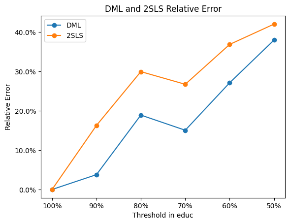

```python
x_labels = ['100%', '90%', '80%', '70%', '60%', '50%']

# Plot the arrays
plt.plot(error_rf, label='DML', marker='o')
plt.plot(error_2sls, label='2SLS', marker='o')

plt.xticks(ticks=range(len(x_labels)), labels=x_labels)

plt.xlabel('Threshold in educ')
plt.ylabel('Relative Error')


plt.legend()

plt.title('DML and 2SLS Relative Error')

plt.gca().yaxis.set_major_formatter(mticker.PercentFormatter(xmax=1))

plt.show()
```

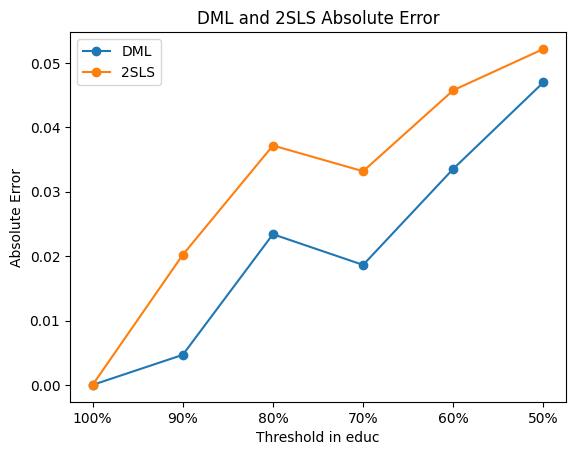

```python
x_labels = ['100%', '90%', '80%', '70%', '60%', '50%']

plt.plot(abs_error_rf, label='DML', marker='o')
plt.plot(abs_error_2sls, label='2SLS', marker='o')

plt.xticks(ticks=range(len(x_labels)), labels=x_labels)


plt.xlabel('Threshold in educ')
plt.ylabel('Absolute Error')

plt.legend()


plt.title('DML and 2SLS Absolute Error')

plt.show()
```

Khi thực hiện ước lượng trên bộ dữ liệu thiếu, kết quả cho thấy sai số của DML nhỏ hơn khi thực hiện *2SLS* - mô hình hồi quy tuyến tính được David Card sử dụng. Khi sai số tương đối và tuyệt đối nhỏ hơn, mô hình sẽ có ước lượng chính xác hơn.

Xét trên bối cảnh thực tế, việc loại bỏ dữ liệu như trên có thể được giải thích nếu như trong quá trình thu thập dữ liệu, chúng ta không thể tiếp cận những người có học vấn cao và không có trường đại học tại khu vực họ sinh sống. Trên thực tế, bộ dữ liệu khi thu thập hầu như đều không thể đảm bảo đại diện cho cả một quần thể, việc ước lượng dựa trên mô hình tuyến tính hoàn toàn có thể bị thiên lệch.

Kết quả trên cho thấy các ước lượng DML gần với ước lượng thu được khi bộ dữ liệu đầy đủ hơn so với hồi quy tuyến tính. Điều đó cho thấy thiên lệch xảy ra ảnh hưởng đến hồi quy tuyến tính nhiều hơn so với DML, qua đó làm nổi bật ưu điểm của DML so với các phương thức hồi quy tuyến tính *Linear Regression*, *2SLS*,...

## Tài liệu tham khảo

Chernozhukov, V., Chetverikov, D., Demirer, M., Duflo, E., Hansen, C., Newey, W., and Robins, J. 2018. "Double/debiased machine learning for treatment and structural parameters." The Econometrics Journal, 21: C1-C68. doi:10.1111/ectj.12097.

Bach, P., Chernozhukov, V., Kurz, M. S., and Spindler, M. 2022. "DoubleML - An Object-Oriented Implementation of Double Machine Learning in Python." Journal of Machine Learning Research, 23(53): 1-6. Available at: https://www.jmlr.org/papers/v23/21-0862.html.

Bach, P., Chernozhukov, V., Kurz, M. S., Spindler, M., and Klaassen, S. 2024. "DoubleML - An Object-Oriented Implementation of Double Machine Learning in R." Journal of Statistical Software, 108(3): 1-56. doi:10.18637/jss.v108.i03, arXiv:2103.09603.

Card, David. 1995. "Aspects of Labour Economics: Essays in Honour of John Vanderkamp." In University of Toronto Press.